# Time to Play Normal

(a) The distribution of the random variable $X$, the annual rate of return for this particular mutual fund, is provided below.

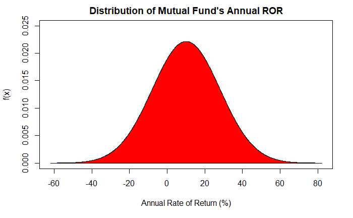

```r
curve(dnorm(x,10.1, 18), 10.1 - (4*18), 10.1 + (4*18), xlim=c(10.1 - (4*18), 10.1 + (4*18)), ylim=c(0, 0.025), xlab = "Annual Rate of Return (%)", ylab="f(x)", main="Distribution of Mutual Fund's Annual ROR", type="l", col='blue', lty=1)
# axis(1, at=c(30, 50), labels=c(30,50))
x7.cor = c(10.1 - (4*18), seq(10.1 - (4*18), 10.1 + (4*18), 0.01), 10.1 + (4*18))
y7.cor = c(0, dnorm(seq(10.1 - (4*18), 10.1 + (4*18), 0.01), 10.1, 18), 0)
polygon(x7.cor, y7.cor,col='red')
```

2. To compute $P(X > 30)$,

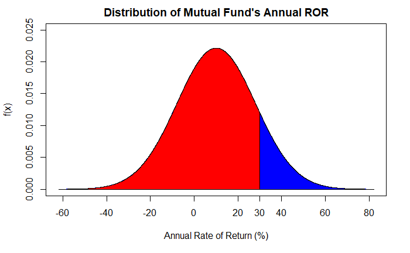

```r
1 - pnorm(30, 10.1, 18)
```

```
[1] 0.1344595
```

and $P(X > 30) = 0.13445945 \approx 0.1345$, or $13.45$%.

3. Referring to part (b), the $P(-30 \leq X \leq 0)$ is

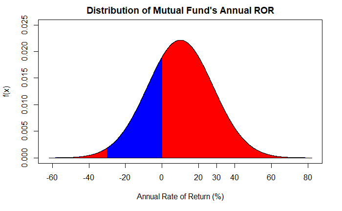

```r
pnorm(0, 10.1, 18) - pnorm(-30, 10.1, 18)  #P(X <= 0) - P(X <= -30)
```

```
[1] 0.2744132
```

and $P(-30 \leq X \leq 0) = 0.2744$. The chance/probability of this year’s rate of return for this particular mutual fund is *somewhere* between -30% and 0% is $0.2744$, or about 27.44%.

4. To compute the value of $x_{10}$ and $x_{90}$, the 10th and 90th percentiles respectively:

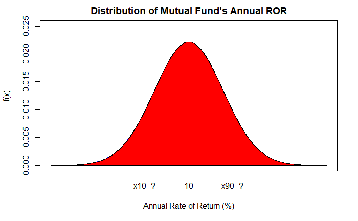

To find each, use the `qnorm` command:

```r
qnorm(0.10, 10.1, 18) #finds the 10th percentile of the Normal with mean=10.1 and sd=18
```

```
[1] -12.96793
```

```r
qnorm(0.90, 10.1, 18) #finds the 10th percentile of the Normal with mean=10.1 and sd=18
```

```
[1] 33.16793
```

from which $x_{10} = -12.96793$% and $x_{90} = 33.16793$%. How should these percentiles be interpreted?

- 10% of the time, the annual rate of return is *at most* -12.96793%
- 90% of the time, this mutual fund has an annual rate of return of at most 33.16793%, or exceeds this rate of return 10% of the time

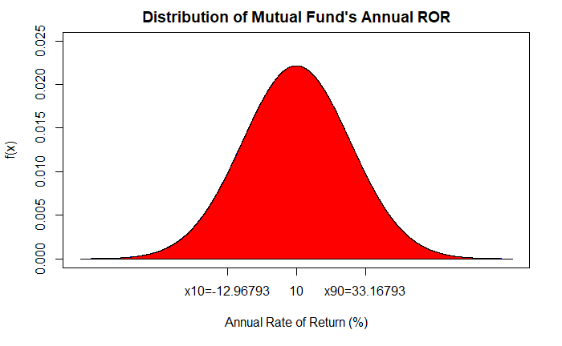